# Sine Waves

## Clipped

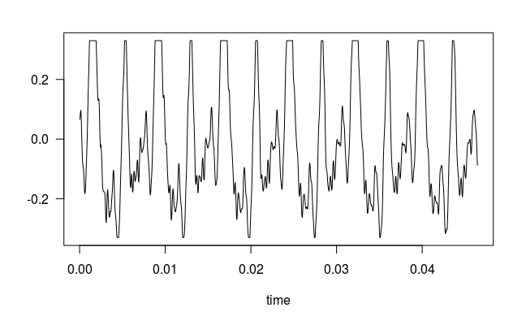

```r
wave10a <- wave10
wave10a@left <- ifelse( abs( wave10a@left ) < 0.33
                      , wave10a@left
                      , 0.33 * sign( wave10a@left )
                      )
plot( extractWave( wave10a, from = 4 * 2048 + 1, to = 5 * 2048))
```

```r
play( bind( wave10, wave10a ) )
```

[output not shown]

The added “noise” comes from the clipping. The most common place for clipping to occur is when the input signal amplitude to the sound input device is too large for the device to convert, and it saturates the analog-to-digital converter. However, it can also occur with an analog amplifier because they all have amplitude limits as well. Since sound analog signals are often passed through pre-amplifiers and then amplifiers before reaching the A/D converter, the pre-amp can be over-driven and then the regular amp may reduce the amplitude such that the amplitude as seen by the computer may not always be near the computer maximum.

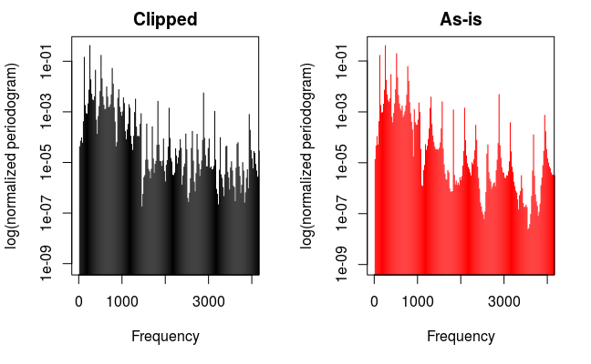

```r
pergm10a <- periodogram( wave10a, width = 2048, overlap = 0.5 )
par( mfrow=c( 1, 2 ) )
plot( pergm10a, xlim = c( 0, 4000 ), log="y", which=4, main="Clipped" )
plot( pergm10, xlim = c( 0, 4000 ), log="y", col="red", which = 4, main="As-is" )
```

We can see that the clipped version has many more intermediate frequencies in the overtones, while the as-is version is much more selective about which overtones are emphasized.

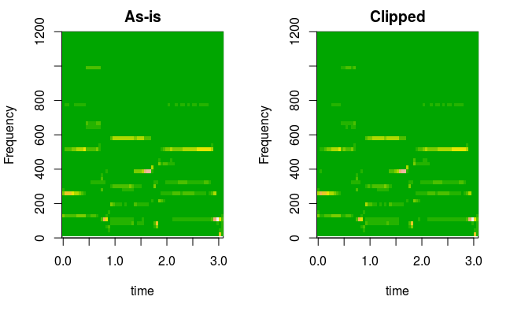

```r
par( mfrow=c( 1, 2 ) )
image( pergm10, ylim = c( 0, 1200 ), xunit="time", col=terrain.colors( 12 ), main="As-is" )
image( pergm10a, ylim = c( 0, 1200 ), xunit="time", col=terrain.colors( 12 ), main="Clipped" )
```

The spectrogram resolution here is a bit too coarse to see the little spikes in between the main frequencies.